# Analisis Regresi Kuliah-7

Muhammad Firlan Maulana

2024-03-05

## Packages

```r
library(readxl)
library(lmtest)
library(car)
library(randtests)
library(tidyverse)
```

```r
library(plotly)
library(nortest)
```

## Data

```r
data7 = read_xlsx("D:/firlan/Documents/College/Semester 4/Analisis Regeresi/Kuliah 7/Anreg Individu.xlsx")

head(data7)
```

```
## # A tibble: 6 × 2
##       X     Y
##   <dbl> <dbl>
## 1     2    54
## 2     5    50
## 3     7    45
## 4    10    37
## 5    14    35
## 6    19    25
```

# Model Regresi Awal

```r
model = lm(formula = Y ~., data=data7)
summary(model)
```

```
##
## Call:
## lm(formula = Y ~ ., data = data7)
##
## Residuals:
##     Min      1Q  Median      3Q     Max
## -7.1628 -4.7313 -0.9253  3.7386  9.0446
##
## Coefficients:
##             Estimate Std. Error t value Pr(>|t|)
## (Intercept) 46.46041    2.76218   16.82 3.33e-10 ***
## X           -0.75251    0.07502  -10.03 1.74e-07 ***
## ---
## Signif. codes:  0 '***' 0.001 '**' 0.01 '*' 0.05 '.' 0.1 ' ' 1
##
## Residual standard error: 5.891 on 13 degrees of freedom
## Multiple R-squared:  0.8856, Adjusted R-squared:  0.8768
## F-statistic: 100.6 on 1 and 13 DF,  p-value: 1.736e-07
```

Didapati bahwa model regresi awal sebagai berikut.

$$\hat Y = 46.46041 - 0.75251X + ε$$

Masih belum diketahui apakah model regresi tersebut merupakan model regresi terbaik. Oleh karena itu, diperlukan eksplorasi kondisi termasuk pengujian asumsi Gauss-Marcov dan normalitas agar dapat diketahui model regresi terbaik.

# Eksplorasi Kondisi

## Scatter Plot Hubungan X dan Y

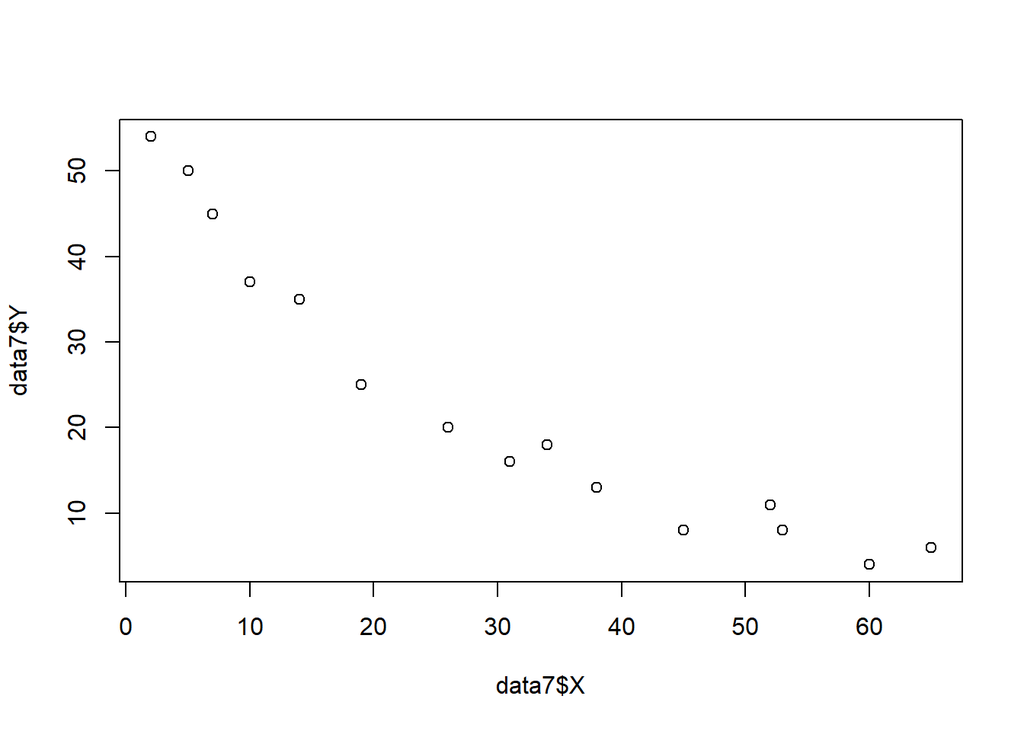

```r
plot(x=data7$X, y=data7$Y)
```

Dari scatter plot hubungan X dan Y di atas, dapat dilihat bahwa tidak terbentuk pola garis lurus namun berbentuk parabola.

# Pemeriksaan Asumsi

## Plot sisaan VS Y duga

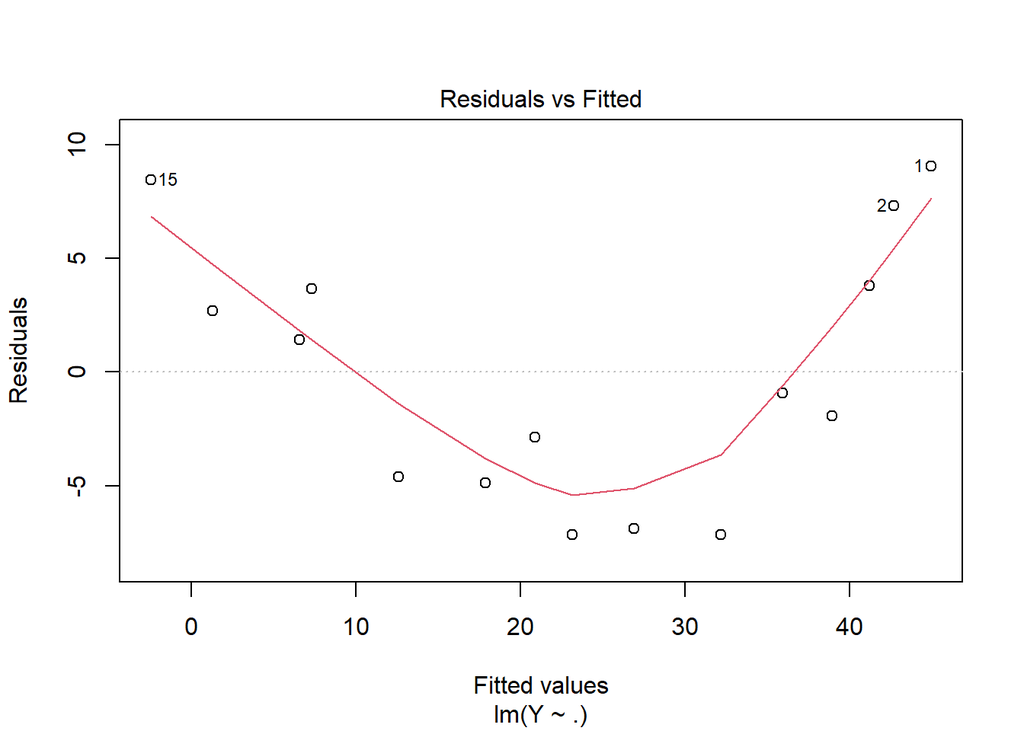

```r
plot(model,1)
```

## Plot sisaan VS Urutan

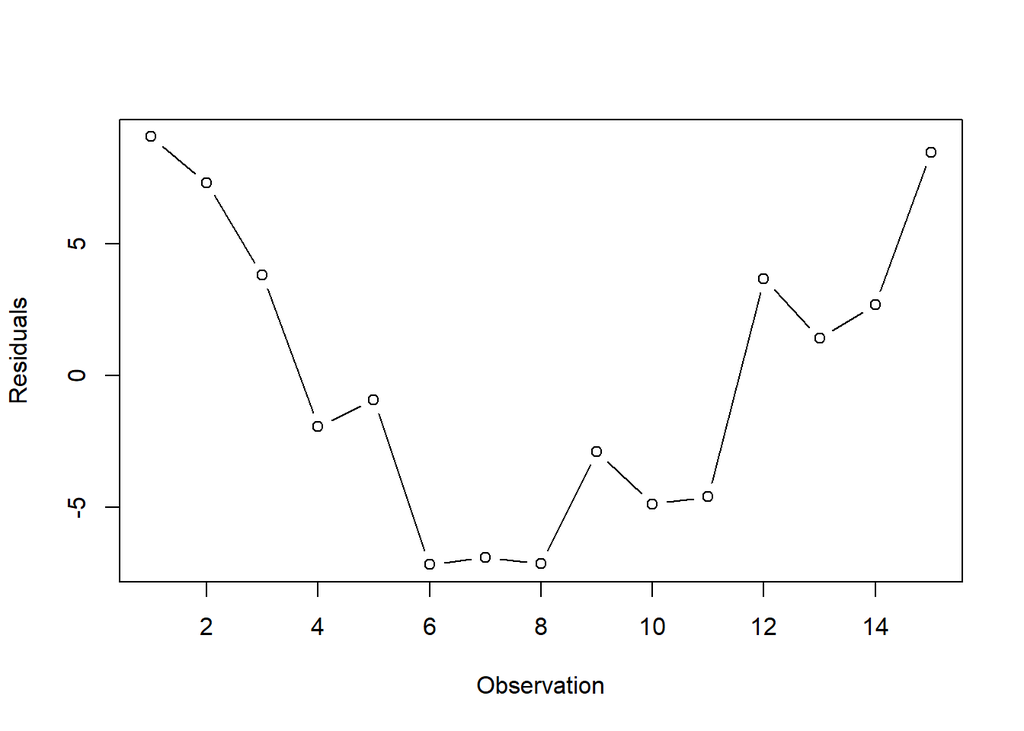

```r
plot(x = 1:dim(data7)[1],
     y = model$residuals,
     type = 'b',
     ylab = "Residuals",
     xlab = "Observation")
```

## Eksplorasi Normalitas Sisaan dengan QQ-plot

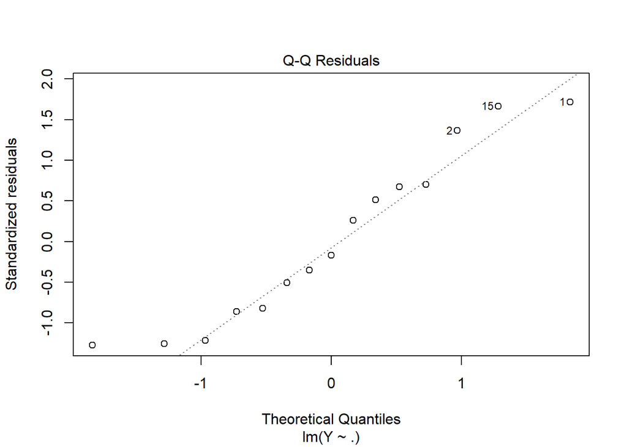

```r
plot(model,2)
```

Terlihat pada QQ-plot tersebut bahwa sisaan menyebar Normal sehingga memenuhi asumsi 𝜀(𝑖~𝑁).

# Uji Formal Kondisi Gauss-Marcov

### 1. Nilai harapan/rataan sisaan sama dengan nol

H0: Nilai harapan sisaan sama dengan 0 H1: Nilai harapan sisaan tidak sama dengan 0

```r
t.test(model$residuals,mu = 0,conf.level = 0.95)
```

```
##
##  One Sample t-test
##
## data:  model$residuals
## t = -4.9493e-16, df = 14, p-value = 1
## alternative hypothesis: true mean is not equal to 0
## 95 percent confidence interval:
##  -3.143811  3.143811
## sample estimates:
##     mean of x
## -7.254614e-16
```

p-value = 1 > alpha = 0.05, sehingga tak tolak H0. Belum terdapat cukup bukti untuk menyatakan bahwa nilai harapan sisaan tidak sama dengan 0.

### 2. Ragam sisaan homogen

H0: Ragam sisaan homogen H1: Ragam sisaan tidak homogen

```r
apakah.homogen = lm(formula = abs(model$residuals) ~ X, # y: abs residual
    data = data7)
summary(apakah.homogen)
```

```
##
## Call:
## lm(formula = abs(model$residuals) ~ X, data = data7)
##
## Residuals:
##     Min      1Q  Median      3Q     Max
## -4.2525 -1.7525  0.0235  2.0168  4.2681
##
## Coefficients:
##             Estimate Std. Error t value Pr(>|t|)
## (Intercept)  5.45041    1.27241   4.284  0.00089 ***
## X           -0.01948    0.03456  -0.564  0.58266
## ---
## Signif. codes:  0 '***' 0.001 '**' 0.01 '*' 0.05 '.' 0.1 ' ' 1
##
## Residual standard error: 2.714 on 13 degrees of freedom
## Multiple R-squared:  0.02385,    Adjusted R-squared:  -0.05124
## F-statistic: 0.3176 on 1 and 13 DF,  p-value: 0.5827
```

```r
bptest(model)
```

```
##
##  studentized Breusch-Pagan test
##
## data:  model
## BP = 0.52819, df = 1, p-value = 0.4674
```

```r
ncvTest(model)
```

```
## Non-constant Variance Score Test
## Variance formula: ~ fitted.values
## Chisquare = 0.1962841, Df = 1, p = 0.65774
```

Didapati bahwa p-value = 0.4674 > alpha = 0.05, sehingga tak tolak H0. Belum cukup bukti untuk menyatakan bahwa ragam sisaan tidak homogen.

### 3. Sisaan saling bebas/tidak ada autokorelasi

H0: Sisaan saling bebas/tidak ada autokorelasi H1: Sisaan tidak saling bebas/ada autokorelasi

```r
runs.test(model$residuals)
```

```
##
##  Runs Test
##
## data:  model$residuals
## statistic = -2.7817, runs = 3, n1 = 7, n2 = 7, n = 14, p-value =
## 0.005407
## alternative hypothesis: nonrandomness
```

```r
dwtest(model)
```

```
##
##  Durbin-Watson test
##
## data:  model
## DW = 0.48462, p-value = 1.333e-05
## alternative hypothesis: true autocorrelation is greater than 0
```

Didapati dari Durbin-Watson bahwa p-value = 0.00001333 < alpha = 0.05, maka tolak H0. Pada taraf nyata 5%, cukup bukti untuk menyatakan bahwa sisaan tidak saling bebas. Asumsi tidak terpenuhi.

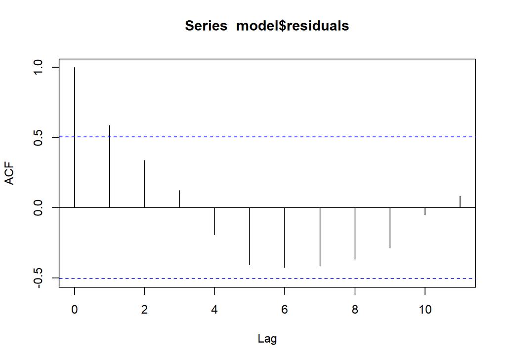

```r
acf(model$residuals)
```

## Uji Formal Normalitas Sisaan

H0: Sisaan menyebar Normal H1: Sisaan tidak menyebar Normal

```r
ks.test(model$residuals, "pnorm", mean=mean(model$residuals), sd=sd(model$residuals))
```

```
##
##  Exact one-sample Kolmogorov-Smirnov test
##
## data:  model$residuals
## D = 0.12432, p-value = 0.9521
## alternative hypothesis: two-sided
```

Didapati bahwa p-value = 0.9521 > alpha = 0.05, tak tolak H0.

```r
shapiro.test(model$residuals)
```

```
##
##  Shapiro-Wilk normality test
##
## data:  model$residuals
## W = 0.92457, p-value = 0.226
```

Didapati bahwa p-value = 0.226 > alpha = 0.05, tak tolak H0.

Dari uji Kolmogorov-Smirnov dan Shapiro-Wilk, keduanya didapati tak tolak H0. Pada taraf nyata 5%, belum cukup bukti untuk menyatakan sisaan tidak menyebar normal.

## Weighted Least Squares

```r
resid_abs <- abs(model$residuals)
fitted_val <- model$fitted.values
fit <- lm(resid_abs ~ fitted_val, data7)
data.weights <- 1 / fit$fitted.values^2
data.weights
```

```
##          1          2          3          4          5          6          7
## 0.03414849 0.03489798 0.03541143 0.03620311 0.03730067 0.03874425 0.04091034
##          8          9         10         11         12         13         14
## 0.04257072 0.04361593 0.04507050 0.04779711 0.05077885 0.05122749 0.05454132
##         15
## 0.05710924
```

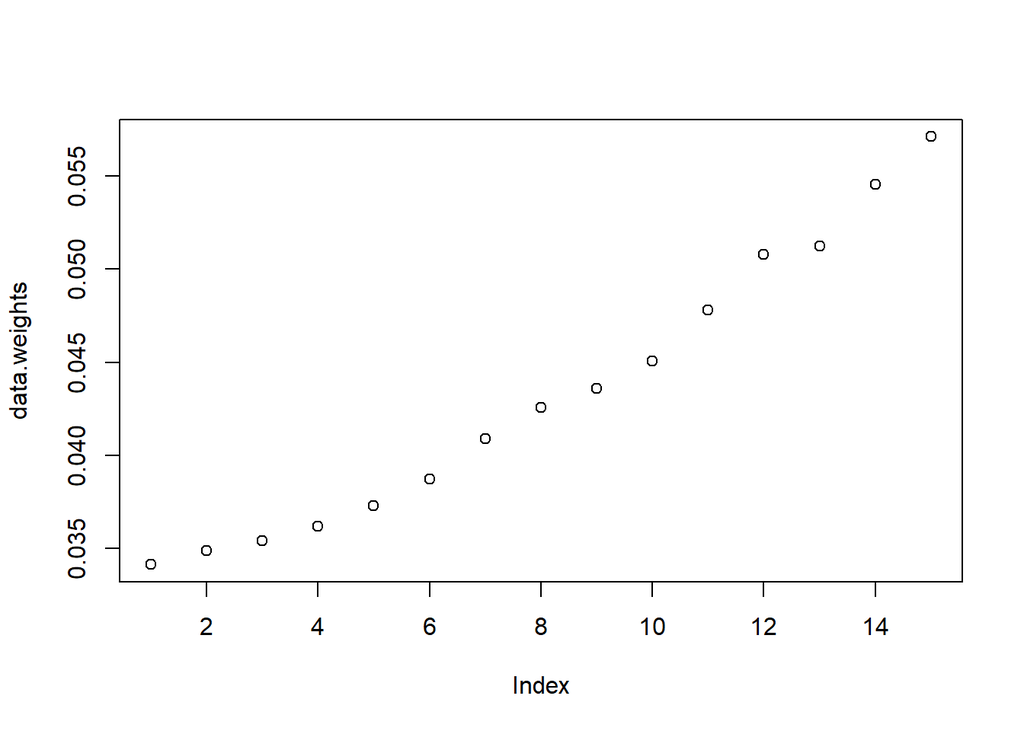

```r
plot(data.weights)
```

Model Regresi yang Terboboti:

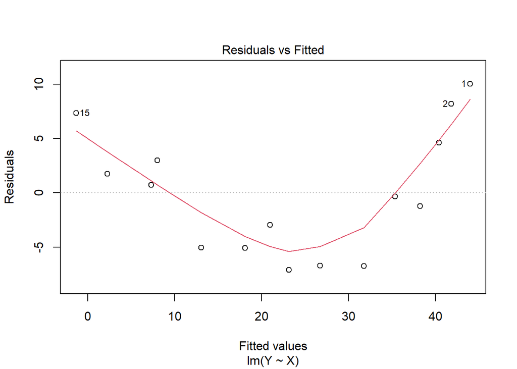

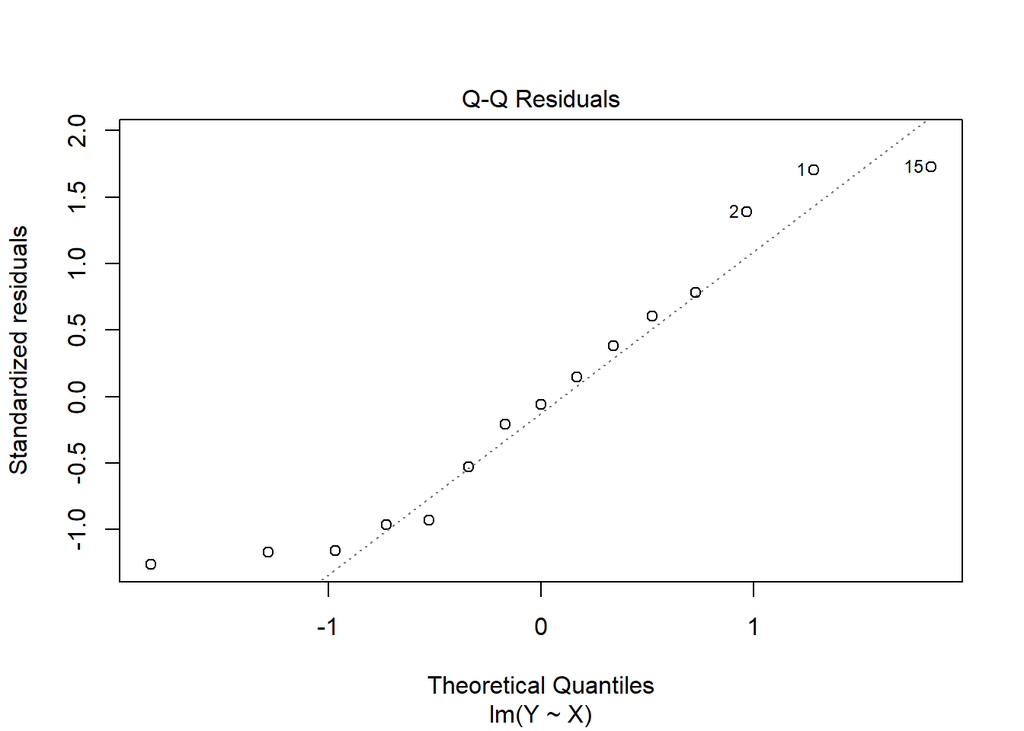

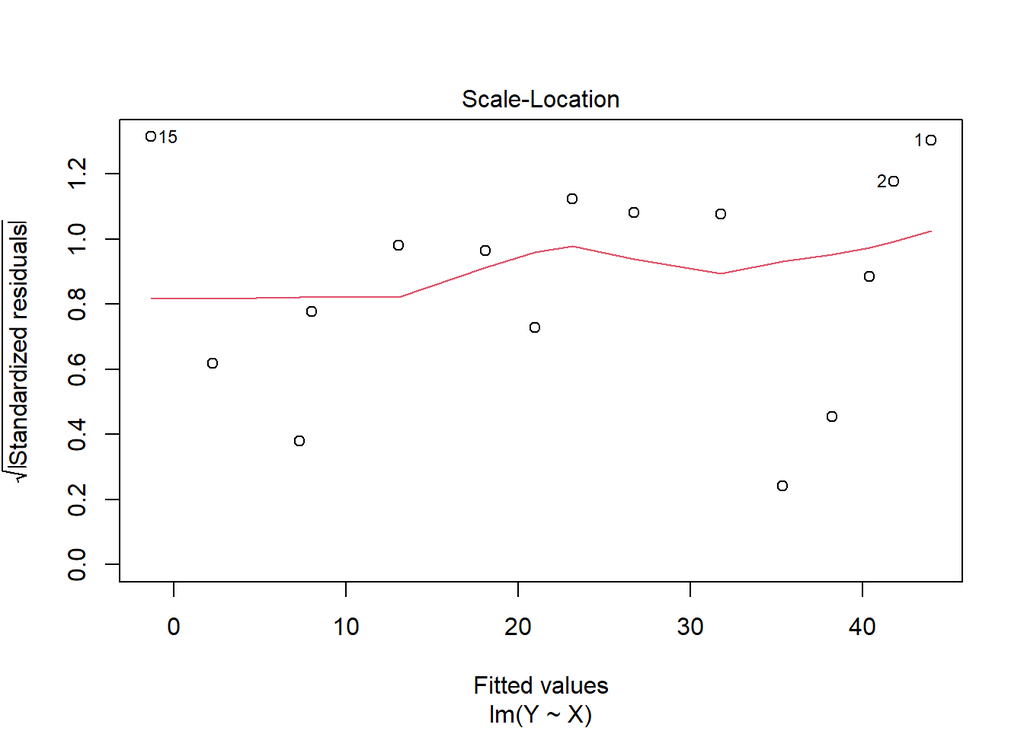

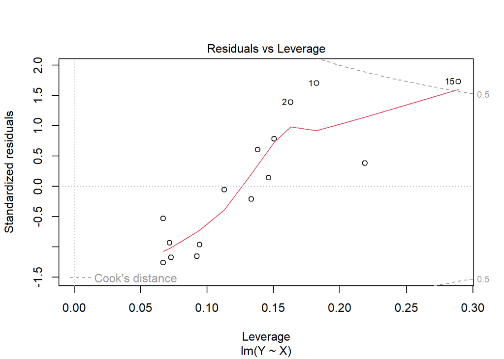

```r
modelweight = lm(Y~X, data = data7, weights = data.weights)
plot(modelweight)
```

```r
summary(modelweight)
```

```
##
## Call:
## lm(formula = Y ~ X, data = data7, weights = data.weights)
##
## Weighted Residuals:
##      Min       1Q   Median       3Q      Max
## -1.46776 -1.09054 -0.06587  0.77203  1.85309
##
## Coefficients:
##             Estimate Std. Error t value Pr(>|t|)
## (Intercept) 45.41058    2.90674  15.623 8.35e-10 ***
## X           -0.71925    0.07313  -9.835 2.18e-07 ***
## ---
## Signif. codes:  0 '***' 0.001 '**' 0.01 '*' 0.05 '.' 0.1 ' ' 1
##
## Residual standard error: 1.204 on 13 degrees of freedom
## Multiple R-squared:  0.8815, Adjusted R-squared:  0.8724
## F-statistic: 96.73 on 1 and 13 DF,  p-value: 2.182e-07
```

Transformasi WLS di atas menunjukan bahwa WLS belum efektif dalam mentransformasukan model regresi. Hal tersebut dikatakan demikian karena berdasarkan eksplorasi di atas, asumsi Gauss-Marcov belum terpenuhi.

Didapati model sebagai berikut.
$$\hat Y = 45.41058 - 0.71925X + e$$

## OLS vs WLS

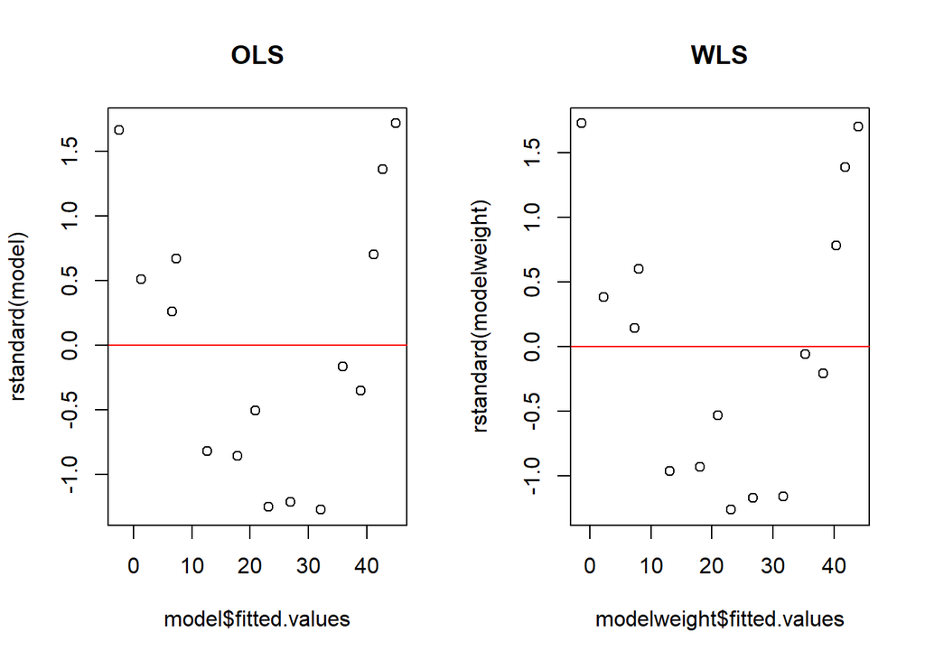

```r
par(mfrow=c(1,2))
plot(y = rstandard(model),
     x = model$fitted.values,
     main="OLS")
abline(h=0, col="red")
plot(y = rstandard(modelweight),
     x = modelweight$fitted.values,
     main="WLS")
abline(h=0, col="red")
```

# Penyesuasian pada Data

## Transformasi Akar pada X, Y, atau X dan Y

```r
dataakar = data7 %>% mutate(Yakar = sqrt(Y)) %>% mutate(Xakar = sqrt(X))
dataakar
```

```
## # A tibble: 15 × 4
##        X     Y Yakar Xakar
##    <dbl> <dbl> <dbl> <dbl>
##  1     2    54  7.35  1.41
##  2     5    50  7.07  2.24
##  3     7    45  6.71  2.65
##  4    10    37  6.08  3.16
##  5    14    35  5.92  3.74
##  6    19    25  5     4.36
##  7    26    20  4.47  5.10
##  8    31    16  4     5.57
##  9    34    18  4.24  5.83
## 10    38    13  3.61  6.16
## 11    45     8  2.83  6.71
## 12    52    11  3.32  7.21
## 13    53     8  2.83  7.28
## 14    60     4  2     7.75
## 15    65     6  2.45  8.06
```

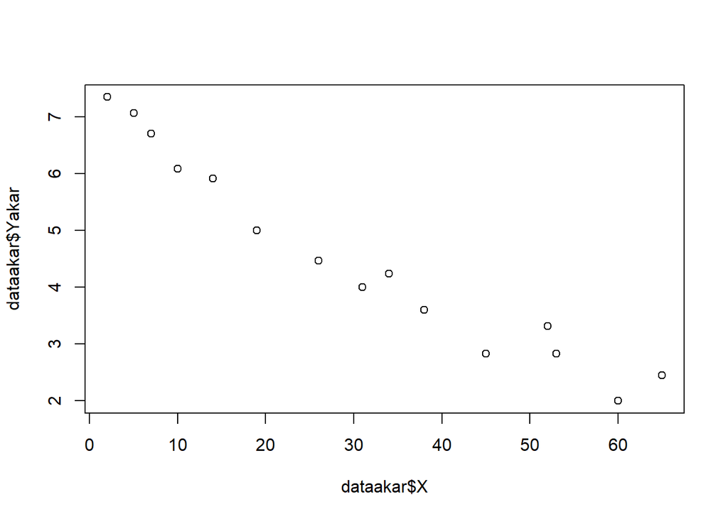

```r
plot(x = dataakar$X, y = dataakar$Yakar)
```

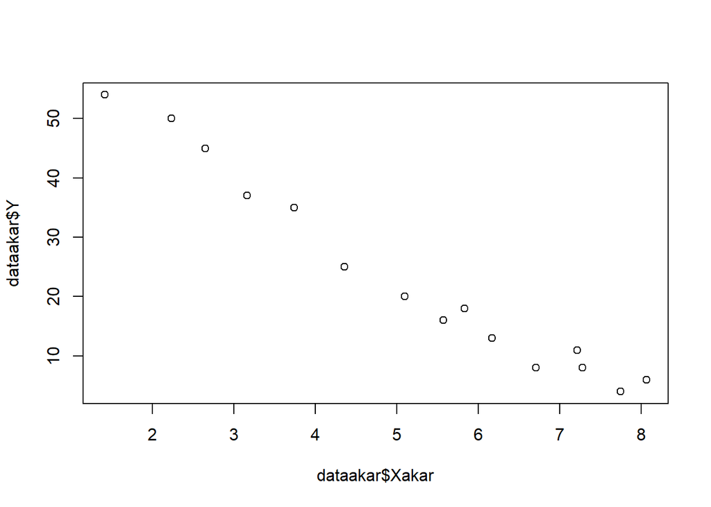

```r
plot(x = dataakar$Xakar, y = dataakar$Y)
```

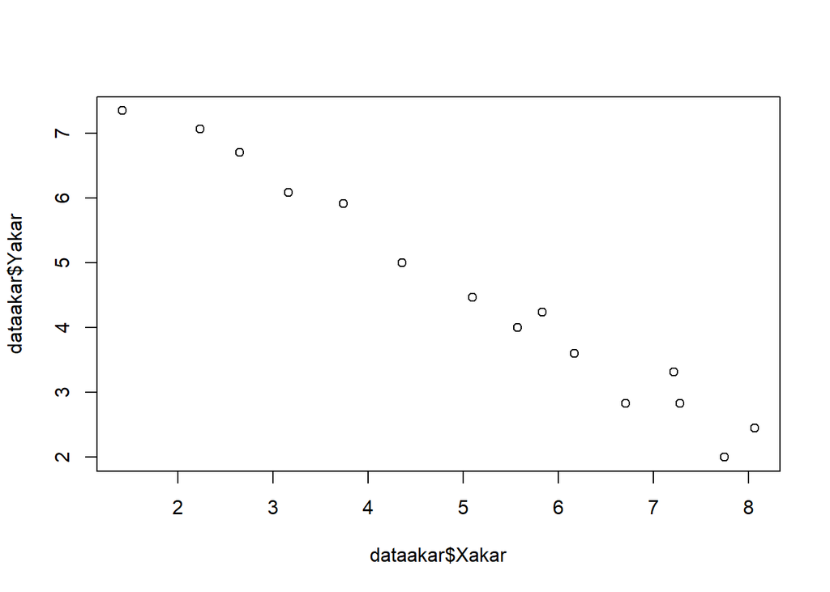

```r
plot(x = dataakar$Xakar, y = dataakar$Yakar)
```

```r
data.sqrt = data.frame(dataakar$Xakar, dataakar$Yakar)
```

Diketahui di awal bahwa hubungan antara X dan Y cenderung membentuk pola parabola dan nilai B1 < 0, sehingga diperlukan transformasi data dengan mengecilkan nilai X dan/atau Y. Transformasi mengecilkan tersebut dapat dilakukan dengan membentuk X dan/atau Y menjadi akar atau pangkat setengah dari data asli.

Uji nonformal dilakukan melalui plot hubungan Xakar dengan Y, X dengan Yakar, dan Xakar dengan Yakar. Terlihat perbedaan dari masing-masing plot, sehingga dirasa perlu untuk diadakan uji lebih lanjut dalam rangka memperoleh model terbaik. Pemeriksaan asumsi dilakukan pada data dengan sisaan paling bebas.

# Model Asumsi dan Pemeriksaannya

## Xakar dengan Y

```r
modelXakar = lm(formula = dataakar$Y ~ dataakar$Xakar)
summary(modelXakar)
```

```
##
## Call:
## lm(formula = dataakar$Y ~ dataakar$Xakar)
##
## Residuals:
##     Min      1Q  Median      3Q     Max
## -4.4518 -2.8559  0.7657  2.0035  5.2422
##
## Coefficients:
##                Estimate Std. Error t value Pr(>|t|)
## (Intercept)     63.2250     2.2712   27.84 5.67e-13 ***
## dataakar$Xakar  -7.7481     0.4097  -18.91 7.68e-11 ***
## ---
## Signif. codes:  0 '***' 0.001 '**' 0.01 '*' 0.05 '.' 0.1 ' ' 1
##
## Residual standard error: 3.262 on 13 degrees of freedom
## Multiple R-squared:  0.9649, Adjusted R-squared:  0.9622
## F-statistic: 357.7 on 1 and 13 DF,  p-value: 7.684e-11
```

Didapati model sebagai berikut.
$$\hat Y = 63.2250 - 7.7481 X^{\frac{1}{2}} + \epsilon$$

Dilakukan Durbin-Watson test

```r
dwtest(modelXakar)
```

```
##
##  Durbin-Watson test
##
## data:  modelXakar
## DW = 1.1236, p-value = 0.01422
## alternative hypothesis: true autocorrelation is greater than 0
```

Diperoleh nilai p-value = 0.01422 < alpha = 0.05, sehingga tolak H0. Pada taraf 5% terdapat cukup bukti untuk menyatakan bahwa sisaan tidak saling bebas. Hal ini mengakibatkan asumsi tidak terpenuhi sehingga model tersebut bukanlah model terbaik.

## X dengan Yakar

```r
modelYakar = lm(formula = dataakar$Yakar ~ dataakar$X)
summary(modelYakar)
```

```
##
## Call:
## lm(formula = dataakar$Yakar ~ dataakar$X)
##
## Residuals:
##      Min       1Q   Median       3Q      Max
## -0.53998 -0.38316 -0.01727  0.36045  0.70199
##
## Coefficients:
##              Estimate Std. Error t value Pr(>|t|)
## (Intercept)  7.015455   0.201677   34.79 3.24e-14 ***
## dataakar$X  -0.081045   0.005477  -14.80 1.63e-09 ***
## ---
## Signif. codes:  0 '***' 0.001 '**' 0.01 '*' 0.05 '.' 0.1 ' ' 1
##
## Residual standard error: 0.4301 on 13 degrees of freedom
## Multiple R-squared:  0.9439, Adjusted R-squared:  0.9396
## F-statistic: 218.9 on 1 and 13 DF,  p-value: 1.634e-09
```

Didapati model sebagai berikut.
$$\hat Y^{\frac{1}{2}}=7.015455 - 0.081045X +\epsilon$$
Dilakukan Durbin-Watson test

```r
dwtest(modelYakar)
```

```
##
##  Durbin-Watson test
##
## data:  modelYakar
## DW = 1.2206, p-value = 0.02493
## alternative hypothesis: true autocorrelation is greater than 0
```

Dari uji Durbin-Watson didapati bahwa p-value = 0.02493 < alpha = 0.05, tolak H0. Pada taraf 5% terdapat cukup bukti menyatakan bahwa sisaan tidak saling bebas. Hal ini mengakibatkan asumsi tidak terpenuhi sehingga model tersebut bukanlah model terbaik.

## Xakar dengan Yakar

```r
modelXYakar = lm(formula = dataakar$Yakar ~ dataakar$Xakar)
summary(modelXYakar)
```

```
##
## Call:
## lm(formula = dataakar$Yakar ~ dataakar$Xakar)
##
## Residuals:
##      Min       1Q   Median       3Q      Max
## -0.42765 -0.17534 -0.05753  0.21223  0.46960
##
## Coefficients:
##                Estimate Std. Error t value Pr(>|t|)
## (Intercept)     8.71245    0.19101   45.61 9.83e-16 ***
## dataakar$Xakar -0.81339    0.03445  -23.61 4.64e-12 ***
## ---
## Signif. codes:  0 '***' 0.001 '**' 0.01 '*' 0.05 '.' 0.1 ' ' 1
##
## Residual standard error: 0.2743 on 13 degrees of freedom
## Multiple R-squared:  0.9772, Adjusted R-squared:  0.9755
## F-statistic: 557.3 on 1 and 13 DF,  p-value: 4.643e-12
```

Didapati model sebagai berikut.
$$\hat Y^{\frac{1}{2}}=8.71245 - 0.81339X^{\frac{1}{2}} + \epsilon$$
Dilakukan Durbin-Watson test

```r
dwtest(modelXYakar)
```

```
##
##  Durbin-Watson test
##
## data:  modelXYakar
## DW = 2.6803, p-value = 0.8629
## alternative hypothesis: true autocorrelation is greater than 0
```

Dari Durbin-Watson test didapati bahwa p-value = 0.8629 > alpha = 0.05, tak tolak H0. Pada taraf nyata 5%, belum cukup bukti untuk menyatakan bahwa sisaan tidak saling bebas. Berdasarkan uji autokorelasi tersebut (Durbin-Watson test) diperoleh hasil bahwa sisaan saling bebas. Namun masih perlu diperiksa dengan uji asumsi lain untuk memastikan bahwa model tersebut merupakan model terbaik.

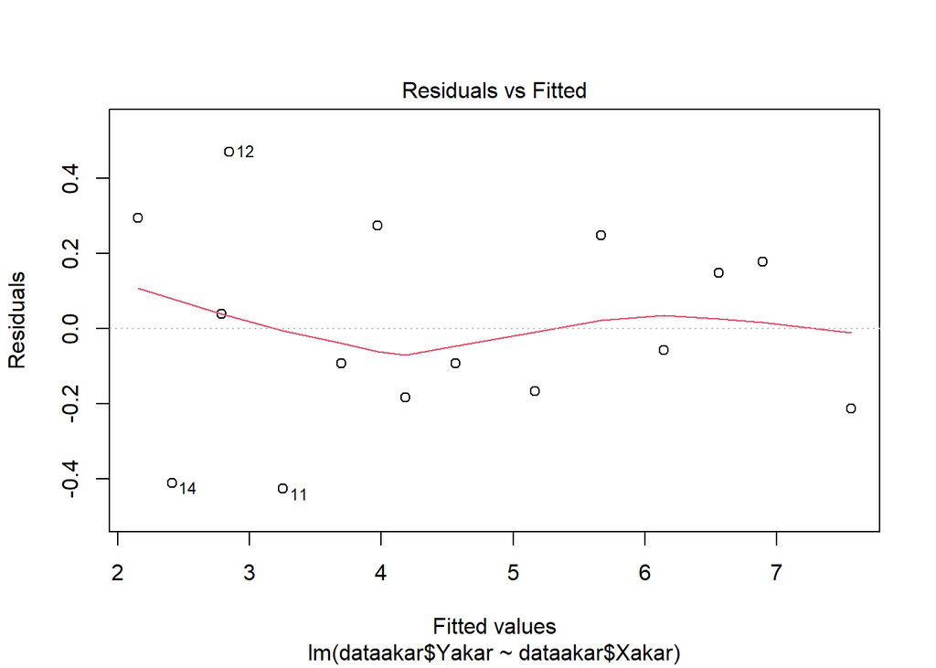

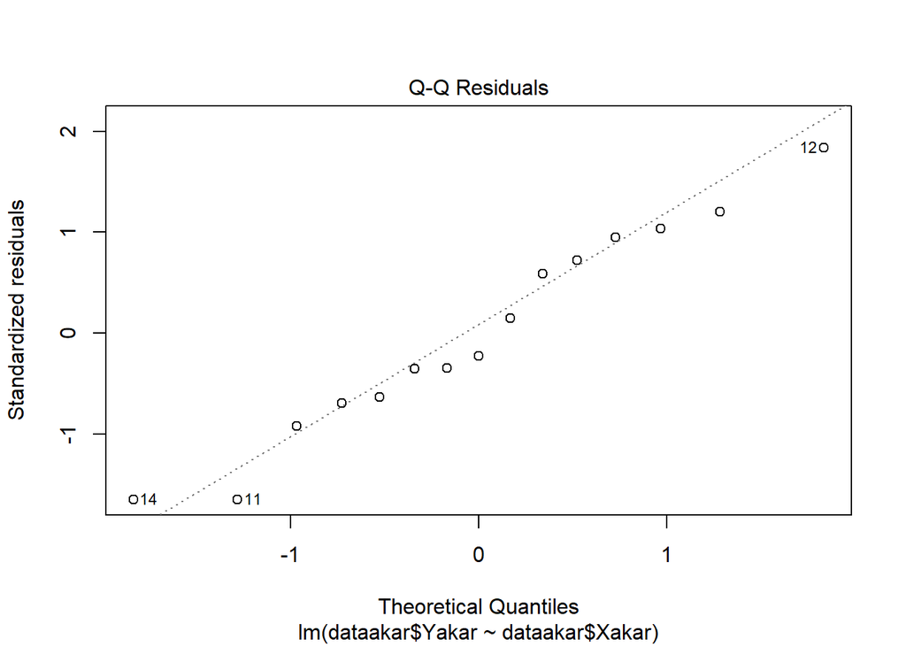

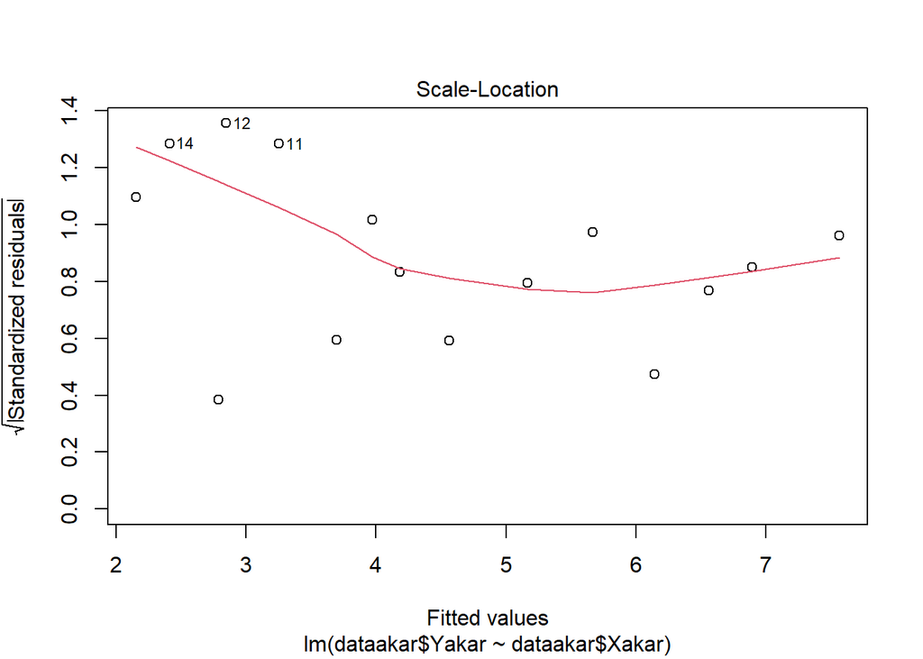

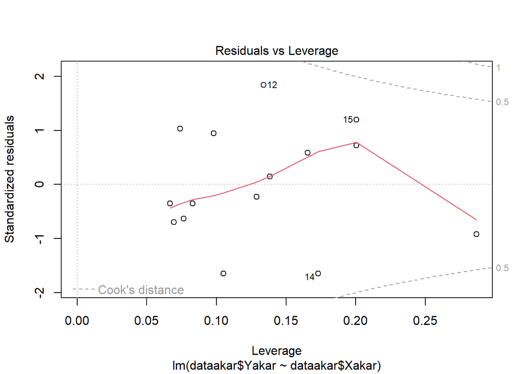

```r
plot(modelXYakar)
```

### 1. Harapan sisaan sama dengan nol

```r
t.test(modelXYakar$residuals, mu = 0, conf.level = 0.95)
```

```
##
##  One Sample t-test
##
## data:  modelXYakar$residuals
## t = 2.0334e-16, df = 14, p-value = 1
## alternative hypothesis: true mean is not equal to 0
## 95 percent confidence interval:
##  -0.1463783  0.1463783
## sample estimates:
##    mean of x
## 1.387779e-17
```

p-value = 1 > alpha = 0.05, tak tolak H0. Pada taraf nyata 5%, belum terdapat cukup bukti untuk menyatakan bahwa nilai harapan sisaan tidak sama dengan 0.

### 2. Ragam sisaan homogen

```r
ncvTest(modelXYakar)
```

```
## Non-constant Variance Score Test
## Variance formula: ~ fitted.values
## Chisquare = 2.160411, Df = 1, p = 0.14161
```

p-value = 0.14161 > alpha = 0.05, tak tolak H0. Pada taraf nyata 5%, belum terdapat cukup bukti untuk menyatakan bahwa ragam sisaan tidak homogen.

```r
sisaan.modelXYakar = resid(modelXYakar)
(norm.modelXYakar = lillie.test(sisaan.modelXYakar))
```

```
##
##  Lilliefors (Kolmogorov-Smirnov) normality test
##
## data:  sisaan.modelXYakar
## D = 0.11948, p-value = 0.817
```

Karena ketiga asumsi di atas terpenuhi, maka asumsi Gauss-Marcov terpenuhi.

# Kesimpulan dan Transformasi Balik

Setelah melalui berbagai transformasi, didapati bahwa model terbaik dipenuhi ketika variabel X dan Y keduanya ditransformasi ke dalam bentuk akar atau pangkat 1/2. Dikatakan demikian karena semua asumsi dalam analisis regresi linear sederhana dapat terpenuhi. Model terbaik untuk data ini adalah
$$\hat Y^{\frac{1}{2}} = 8.71245 - 0.81339X^{\frac{1}{2}} + \epsilon$$